# 3 Multinomial Regressions in R

Author

Luis Sattelmayer

```r
library(tidyverse)
```

## 3.1 Introduction

In this script, I will show you how to construct a multinomial logistic regression in R. For this, we will work on the *European Social Survey* (ESS) again. These are the main points that are covered in this script:

1. The logic of multinomial (logistic) regressions
2. Advanced Data Management
3. Interpretation of a multinomial Model
4. Model Diagnostics
5. Goodness of Fit
6. APIs and Data Visualization (OPTIONAL!)

## 3.2 The Logic of multinomial (logistic) Regressions

I have chosen four countries out of which you will be able to choose one later on when I ask you to work on some exercises. For now, I will mainly work on Germany. One of the classic applications of multinomial models in political science is the question of voting behavior, more precisely vote choice. Last week, we have seen models of a logistic regression (logit). It is used in cases when our dependent variable (DV) is binary (0 or 1; true or false; yes or no) which means that we are not allowed to use OLS. The idea of logit can be extended to *unordered categorical or nominal variables* with more than **two** categories, e.g.: Vote choice, Religion, Brands…

Instead of one equation modelling the log-odds of $P(X=1)$, we do the same thing but for the amount of categories that we have. In fact, this means that a multinomial model runs several single logistic regressions on something we call a *baseline.* R will choose this baseline to which the categorical values of our DV will then relate. But we can also change it (this is called releveling). This allows us to make very interesting inferences with categorical (or ordinal) variables. If this sounds confusing, you should trust me when I tell you that this will become more straightforward in a second!

However, this also makes the interpretation of these models a bit intricate and opaque at times. Nevertheless, you will see that once you have understood the basic idea of a multinomial regression and how to interpret the values in accordance to the baseline, it is not much different from logistic regressions on binary variables (and in my eyes even a bit simpler…). If the logic of logit is not 100% clear at this point, I recommend you go back to last session’s script on logit and work through my explanations. And if that does not help, try to follow this lecture attentively. As I said, the logic is the same, so I will repeat myself :) And if it is still unclear, you can always ask in class or come see me after the session!

But enough small talk, let’s first do some data wrangling which you all probably dread at this point…

## 3.3 Data Management for Multinomial Regression

The data which we will use for this session is the 9th round of the ESS, fielded in 2018/2019. The goal of this session is to understand predictors that tell us more about why people vote for Populist Radical-Right Parties, henceforth called *PRRP* (Mudde 2007). For this I have two main hypotheses in mind, as well as some predictors which I know are important based on the literature. Finally we also need some control variables which we need to control for in almost any regression analysis using survey data.

My two hypotheses (**H1**) and **H2**) are as follows:

> **H1**: Thinking that immigrants enrich a country’s culture decreases the likelihood of voting for PRRPs.

> **H2**: Having less trust in politicians increases the likelihood of voting for PRRPs rather than for other parties.

Now you might notice two things. First, my hypotheses are relatively self-explanatory and you are absolutely right. They are more than that, they are perhaps even self-evident. But to this, I would just reply that this is supposed to be an easy exercise which is supposed to expose you to a multinomial regression and the logic of it. Second, you might see that my hypotheses are relatively broadly formulated. This is because I would like you, later in class, to choose one of the countries of the 9th wave of the ESS and build a model yourselves. By giving you broad hypotheses, you can do this ;)

```r
# read_csv from the tidyverse package
ess <- read_csv("ESS9e03_1.csv") |>
  # dplyr allows me to select only those variables I want to use later
  select(cntry,
         prtvtdfr,
         prtvede1,
         prtvtddk,
         prtvtdpl,
         imueclt,
         yrbrn,
         eduyrs,
         hinctnta,
         stflife,
         trstplt,
         blgetmg,
         gndr) |>
  # based on the selected variables, I filter the dataframe so that I am only
  # left with the data for Germany and Denmark
  filter(cntry %in% c("DE", "DK"))
```

Again, every transformation and mutation of variables which you see below is done based on my knowledge of the dataset which I solely gained from looking at the code book. The code book can be found on the Moodle page (or the ESS’ website). It is highly important that you get used to reading a code book in general but especially to familiarize yourselves with the data which you will use by looking at the way that the variables are coded **in the code book**. There, for example, you will find information on the numeric values which are stored in the variables `prtvtdfr`, `prtvede1`, `prtvtddk` and `prtvtdpl`. They all stand for a category or, in our case, a party name which you can only identify if you open the code book. You will see that I only selected some parties in the `mutate()` function below. This is more or less to get rid of those parties that did not make it into the national parliament at the last national election of each country.

You have seen a similar chunk of code in the last script. See how, once you have a code that works for one dataset, you can use it again?

```r
ess_clean <- ess |>
  mutate(across(
    where(is.numeric),  # Exclude 'age' while keeping numeric columns
    ~ case_when(
      . %in% c(66, 77, 88, 99, 7777, 8888, 9999) ~ NA_integer_,
      TRUE ~ .
    )
  ),
  gndr = recode(gndr, `1` = 0, `2` = 1),
  blgetmg = case_when(
    blgetmg == 2 ~ 0,
    blgetmg == 1 ~ 1
  ))
```

In fact, you could already build the model now and start the multinomial regression. However, I add an additional data management step by placing the numeric values of the election variable in a new variable called `vote_de`, where I convert the numeric values to character values and at the same time give them the names of the parties. Rows for respondents from other countries (who have no value on the German vote variable) automatically become `NA` in this new variable.

But more importantly, once I run the regression, it will display the parties’ names instead of the numbers. This means that I won’t have to go back to the code book every time to check what the 1s or 2s correspond to.

```r
# this is simple base R creating a new column/variable with character
# values corresponding to the parties' names behind the numeric values
ess_clean$vote_de[ess_clean$prtvede1==1]<-"CDU/CSU"
ess_clean$vote_de[ess_clean$prtvede1==2]<-"SPD"
ess_clean$vote_de[ess_clean$prtvede1==3]<-"Die Linke"
ess_clean$vote_de[ess_clean$prtvede1==4]<-"Grüne"
ess_clean$vote_de[ess_clean$prtvede1==5]<-"FDP"
ess_clean$vote_de[ess_clean$prtvede1==6]<-"AFD"
```

Here is a way to mutate all the variables at once. However, this somehow creates conflicts with a package used further below.

```r
ess_clean <- ess_clean |>
  mutate(
    vote_dk = case_when(prtvtddk == 1 ~ "Socialdemokratiet",
                        prtvtddk == 2 ~ "Det Radikale Venstre",
                        prtvtddk == 3 ~ "Det Konservative Folkeparti",
                        prtvtddk == 4 ~ "SF Socialistisk Folkeparti",
                        prtvtddk == 5 ~ "Dansk Folkeparti",
                        prtvtddk == 6 ~ "Kristendemokraterne",
                        prtvtddk == 7 ~ "Venstre",
                        prtvtddk == 8 ~ "Liberal Alliance",
                        prtvtddk == 9 ~ "Enhedslisten",
                        prtvtddk == 10 ~ "Alternativet",
                        TRUE ~ NA_character_),
    vote_de = case_when(prtvede1 == 1 ~ "CDU/CSU",
                        prtvede1 == 2 ~ "SPD",
                        prtvede1 == 3 ~ "Die Linke",
                        prtvede1 == 4 ~ "Grüne",
                        prtvede1 == 5 ~ "FDP",
                        prtvede1 == 6 ~ "AFD"))
```

## 3.4 Constructing the Model

Now that the data management process is finally over, we can specify our model. For this, you need to install the `nnet` package and load it to your library. Once this is done, we will take the exact same steps as you would do for an OLS or logit model. You specify your DV followed by a `~` and then you only need to add all your IVs. Lastly, you need to specify the data source. `Hess = TRUE` will provide us with a Hessian matrix that we need for a package later. If you don’t know what that is… that is absolutely fine!

```r
library(nnet)
model_de <- multinom(vote_de ~ imueclt  + stflife + trstplt + blgetmg +
                    gndr + yrbrn + eduyrs + hinctnta,
                     data = ess_clean,
                     Hess = TRUE)
model_dk <- multinom(vote_dk ~ imueclt  + stflife + trstplt + blgetmg + gndr +
                     yrbrn + eduyrs + hinctnta,
                     data = ess_clean,
                     Hess = TRUE)
```

### 3.4.1 Re-leveling your DV

In my case, the German PRRP is called *Alternative für Deutschland* meaning it starts with an “A”. R tends to take the alphabetical order as a criterion for the baseline meaning that the baseline for your multinomial model is chosen based on the party which comes first in alphabetical order. Depending on what you want to show, you might want to change the baseline which we can do with the `fct_relevel()` function. If, for instance, we were not interested in vote choice regarding the PRRP but in conservative parties, we could put the German Christian conservative party, the CDU/CSU, as the baseline instead. In the chunk below I show you the mechanics: I set the baselines explicitly (for Germany the AFD, which is what the alphabetical default already gives us; for Denmark the Dansk Folkeparti, the Danish PRRP):

```r
# you need to specify your DV as a factor for this; further, the ref must
# contain the exact character label of the party

# vote_de is still a character vector; converted to a factor, its levels
# default to alphabetical order (AFD first):
ess_clean$vote_de |> as.factor() |> levels()
```

```
[1] "AFD"       "CDU/CSU"   "Die Linke" "FDP"       "Grüne"     "SPD"
```

```r
ess_clean$vote_dk |> as.factor() |> levels()
```

```
 [1] "Alternativet"                "Dansk Folkeparti"
 [3] "Det Konservative Folkeparti" "Det Radikale Venstre"
 [5] "Enhedslisten"                "Kristendemokraterne"
 [7] "Liberal Alliance"            "SF Socialistisk Folkeparti"
 [9] "Socialdemokratiet"           "Venstre"
```

```r
# fct_relevel() moves the chosen category to the first position, which makes
# it the baseline. If we wanted the CDU/CSU as the baseline, we would write
# fct_relevel(as.factor(vote_de), "CDU/CSU"). Below, I explicitly set the
# AFD (Germany) and the Dansk Folkeparti (Denmark) as baselines; for Germany
# this matches the alphabetical default, so our models above are unaffected.
ess_clean <- ess_clean |>
  mutate(vote_de = fct_relevel(as.factor(vote_de), "AFD"),
         vote_dk = fct_relevel(as.factor(vote_dk), "Dansk Folkeparti"))

ess_clean$vote_dk |> levels()
```

```
 [1] "Dansk Folkeparti"            "Alternativet"
 [3] "Det Konservative Folkeparti" "Det Radikale Venstre"
 [5] "Enhedslisten"                "Kristendemokraterne"
 [7] "Liberal Alliance"            "SF Socialistisk Folkeparti"
 [9] "Socialdemokratiet"           "Venstre"
```

## 3.5 Interpreting a Multinomial Model

You already know the `stargazer` package for displaying a regression table. This time we will use another package called `modelsummary` which is developed by [Vincent Arel-Bundock](https://arelbundock.com/) who also develops the `marginaleffects` package that we will see later on. The documentation on the package can be found [here](https://modelsummary.com/articles/modelsummary.html). You might wonder why I am showing you this package as you already know `stargazer`. Modelsummary is much more flexible and compatible with many more model classes than stargazer, which is why I mostly use modelsummary at this point.

```r
modelsummary::modelsummary(
  model_de,
  stars = TRUE,
  # gof_omit = c("AIC|BIC|RMSE"),
  stars_method = "simple",
  coef_map = c(
    "imueclt" = "Positivity Immigration",
    "stflife" = "Satisfaction w/ Life",
    "trstplt" = "Trust in Politicians",
    "blgetmg" = "Ethnic Minority",
    "gndr" = "Gender",
    "yrbrn" = "Year of Birth",
    "eduyrs" = "Education",
    "hinctnta" = "Income"
  ),
  title = "Multinomial Regression Results Germany",
  notes = "Vote Choice is the dependent variable.",
  output = "html",
  fmt = 3,
  shape = model + term ~ response,
  gof_map = tibble::tribble(
    ~raw, ~clean, ~fmt,
    "AIC", "Akaike Inf. Crit.", 2,
    "BIC", "Bayesian Inf. Crit.", 2,
    "logLik", "Log-Likelihood", 2,
    "deviance", "Deviance", 2
  )
)
```

Multinomial Regression Results Germany

|  |  | CDU/CSU | Die Linke | FDP | Grüne | SPD |
| --- | --- | --- | --- | --- | --- | --- |
| (1) | Positivity Immigration | 0.350*** | 0.617*** | 0.326*** | 0.784*** | 0.493*** |
|  |  | (0.063) | (0.080) | (0.076) | (0.075) | (0.065) |
|  | Satisfaction w/ Life | 0.029 | −0.171* | 0.095 | −0.094 | −0.109 |
|  |  | (0.067) | (0.083) | (0.093) | (0.079) | (0.067) |
|  | Trust in Politicians | 0.513*** | 0.281** | 0.424*** | 0.352*** | 0.398*** |
|  |  | (0.077) | (0.092) | (0.090) | (0.085) | (0.078) |
|  | Ethnic Minority | 0.055*** | 0.444*** | 1.086*** | 0.382*** | 0.385*** |
|  |  | (0.002) | (0.001) | (0.001) | (0.002) | (0.002) |
|  | Gender | 0.859*** | 0.240* | 0.572*** | 0.928*** | 0.395*** |
|  |  | (0.103) | (0.095) | (0.095) | (0.137) | (0.112) |
|  | Year of Birth | −0.013*** | 0.007*** | −0.010*** | −0.002*** | −0.016*** |
|  |  | (0.000) | (0.000) | (0.001) | (0.000) | (0.000) |
|  | Education | 0.014 | 0.081 | 0.036 | 0.091+ | 0.040 |
|  |  | (0.051) | (0.059) | (0.060) | (0.055) | (0.052) |
|  | Income | 0.116* | −0.032 | 0.114+ | 0.136* | 0.047 |
|  |  | (0.055) | (0.066) | (0.067) | (0.062) | (0.056) |

+ p < 0.1, * p < 0.05, ** p < 0.01, *** p < 0.001  
Vote Choice is the dependent variable.

```r
modelsummary::get_gof(model_de)
```

```
      aic      bic r.squared adj.r.squared      rmse nobs
1 3941.63 4177.684 0.1076924      0.107229 0.3385528 1402
```

```r
modelsummary::modelsummary(
  model_dk,
  stars = TRUE,
  stars_method = "simple",
  coef_map = c(
    "imueclt" = "Positivity Immigration",
    "stflife" = "Satisfaction w/ Life",
    "trstplt" = "Trust in Politicians",
    "blgetmg" = "Ethnic Minority",
    "gndr" = "Gender",
    "yrbrn" = "Year of Birth",
    "eduyrs" = "Education",
    "hinctnta" = "Income"
  ),
  fmt = 3,
  shape = model + term ~ response
)

modelsummary::get_gof(model_dk)
```

[output not shown]

## 3.6 Interpreting a Multinomial Regression Table

We can see that many many things are going on in this regression table. Let us try to analyze our results step by step.

First of all, we can see that we have many variables that are statistically significant (lots of stars). Remember that stars only tell us about statistical significance, not about whether our model is good or our theory is right. Note also that the baseline was the party *AFD*. You can see this based on the fact that the category AFD which our DV can take on is not given in our table. This means that whenever we see the results where the DV is one of the parties, R has calculated the coefficients based on the logic that the respondent would have voter for *either* the party in the dependent variable *or* the party of the baseline, which in our case is that of the AFD. In more mathematical terms these are several single logistic regressions always with regards to the baseline AFD which are then aggregated to a multinomial regression. And to be slightly more mathematical, this means our DV is technically: $1 = DV$ and then $0 = AFD$.

Therefore, we can interpret the results exactly like we would for a logistic regression. Last week it was about the likelihood of voting abstention, this week it is the likelihood of voting for the CDU/CSU instead of the AFD, or voting for the SPD instead of the AFD, or voting for Die Linke instead of the AFD, and so on. You get the idea hopefully.

Remember that these are the coefficients of logistic regressions. We cannot interpret them linearily like in OLS. For now, the regression table tells us something about the statistical significance of our predictors and the direction of association: whether or not a statistically significant predictor increases or decreases the likelihood of voting for either or.

### 3.6.1 The Hypotheses

As a reminder, these were my initial (frankly also bad) hypotheses:

> **H1**: Thinking that immigrants enrich a country’s culture decreases the likelihood of voting for PRRPs.

> **H2**: Having less trust in politicians increases the likelihood of voting for PRRPs rather than for other parties.

I am now interested to see the effect of positivity toward migration and trust in politicians *on* the vote choice for each party *instead* of the AFD. What we can see is that a one-unit increase in positive attitudes toward migration (thinking that immigrants culturally enrich the respondents’ country) raises the likelihood for voting for all other parties *instead* of voting for the AFD. In the case of the first column, in which the vote was either for the CDU/CSU or the AFD, a one unit increase in stances on immigration results in a higher likelihood of voting for the CDU/CSU than the AFD.

If we now turn to trust in politicians and this variable’s effect on vote choice for the different German parties, we can see that overall there is a statistically significant a positive association with having more trust in politicians and also voting for other parties than the AFD. In return, this also means that low trust in politicians raises the likelihood of voting for the AFD.

You could obviously exponentiate the values that we have here in order to get the odds-ratio. But I have tortured you enough with ORs and predicted probabilities are much more intuitively interpreted. Therefore, we will calculate them in the next section.

## 3.7 Predicted Probabilities

You all hopefully still remember the idea of *predicted probabilities* which we have already seen last time for a simply logistic regression. You hold all but one predictor variables (IVs) constant at their mean or another logical value. The one predictor which you do not hold constant you let alternate/vary to estimate the predicted probabilities of this specific variable of interest and the different values it can take on (on your dependent variable). The predicted probabilities can be tricky to code manually and we are not going to do this again but we will use a package that can do this for us.

The text below is the outdated version of how I calculate predicted probabilities for multinomial models. I still leave it in here because it is still working but I recommend working with the `marginaleffects`.

The package is called `MNLpred` and allows us to specify the variable of interest. This package simulates our coefficients n-times (we tell it how many times to run the simulation) by drawing from a multivariate normal distribution centered on our estimated coefficients – a simulation approach in the spirit of Bayesian statistics (King et al. (2000)) – and then takes the mean value of all of our simulations. This way, we end up more or less with the same predicted probabilities that we have seen last week. These are much more easily interpreted than relative risk ratios (the odds-ratios of multinomial regressions) and can be plotted.

```r
library(MNLpred)
pred1 <- mnl_pred_ova(
  model = model_de,
  # specify data source
  data = ess_clean,
  # specify predictor of interest
  x = "imueclt",
  # the steps which should be used for the simulated prediction
  by = 1,
  # this would be for replicability, we do not care about it
  # here
  seed = "random",
  # number of simulations
  nsim = 100,
  # confidence intervals
  probs = c(0.025, 0.975)
)
```

```
Multiplying values with simulated estimates:
================================================================================
Applying link function:
================================================================================
Done!
```

```r
pred1$plotdata |> head()
```

```
  imueclt vote_de       mean      lower      upper
1       0     AFD 0.24054441 0.17816317 0.30767055
2       1     AFD 0.18700754 0.14250578 0.23640779
3       2     AFD 0.14078191 0.11338369 0.17352291
4       3     AFD 0.10251825 0.08547106 0.12080326
5       4     AFD 0.07221653 0.05913101 0.08726758
6       5     AFD 0.04926249 0.03751884 0.06223509
```

Let’s simulate the exact same thing for our second hypothesis regarding the trust in politicians:

```r
pred2 <- mnl_pred_ova(
  model = model_de,
  data = ess_clean,
  x = "trstplt",
  by = 1,
  seed = "random",
  nsim = 100,
  probs = c(0.025, 0.975)
)
```

```
Multiplying values with simulated estimates:
================================================================================
Applying link function:
================================================================================
Done!
```

The results, which we have both stored respectively in the objects `pred1` and `pred2` can be used for a visualization with `ggplot()`.

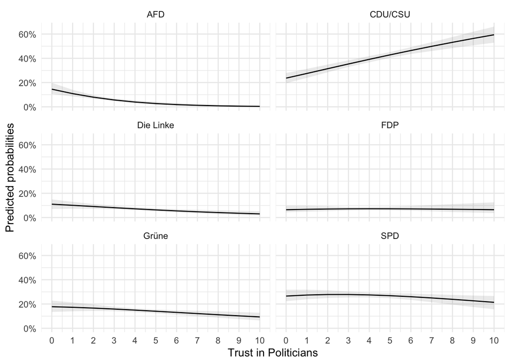

```r
library(ggplot2)
ggplot(data = pred2$plotdata, aes(
  x = trstplt,
  y = mean,
  ymin = lower,
  ymax = upper
)) +
  # this gives us the confidence intervals
  geom_ribbon(alpha = 0.1) +
  # taking the mean of the values
  geom_line() +
  # here we display the predicted probabilities for all parties in one plot
  facet_wrap(. ~ vote_de, ncol = 2) +
  # putting the values of the y-axis in percentages
  scale_y_continuous(labels = scales::percent_format(accuracy = 1)) +
  # the x-axis follows the 0-10 scale of the predictor
  scale_x_continuous(breaks = c(0:10)) +
  # specifying the ggplot theme
  theme_minimal() +
  # lastly you only need to label your axes; Always label your axes ;)
  labs(y = "Predicted probabilities",
       x = "Trust in Politicians")
```

Here we can see very well how the predicted probability of voting for each party increases or decreases as our predictor, trust in politicians, increases (increasing values mean more trust in politicians).

We can also visualize our predicted probabilities in one single plot. I made the effort of coordinating the colors so that they would be displayed in the colors of the parties. If you want a color selector to get the HEX color codes, you can use [Google’s color picker](https://www.google.com/search?q=color+picker). Recent versions of RStudio will also display a small preview of the color you have selected directly in the editor.

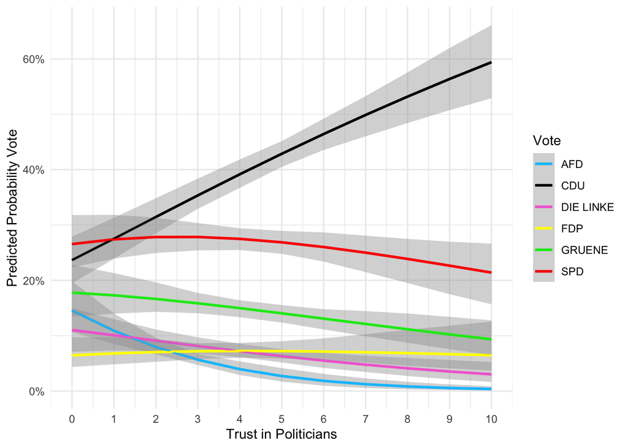

```r
ggplot(data = pred2$plotdata, aes(
  x = trstplt,
  y = mean,
  color = as.factor(vote_de)
)) +
  geom_smooth(aes(ymin = lower, ymax = upper), stat = "identity") +
  geom_line() +
  scale_y_continuous(labels = scales::percent_format(accuracy = 1)) +
  scale_x_continuous(breaks = c(0:10)) +
  scale_color_manual(
    values = c(
      "#03c2fc",
      "#000000",
      "#f26dd5",
      "#FFFF00",
      "#00e81b",
      "#fa0000"
    ),
    name = "Vote",
    labels = c("AFD", "CDU", "DIE LINKE", "FDP",
               "GRUENE", "SPD")
  ) +
  ylab("Predicted Probability Vote") +
  xlab("Trust in Politicians") +
  theme_minimal()
```

This here is the plot for our first hypothesis for which we have stored the predicted probabilities in the object `pred1`:

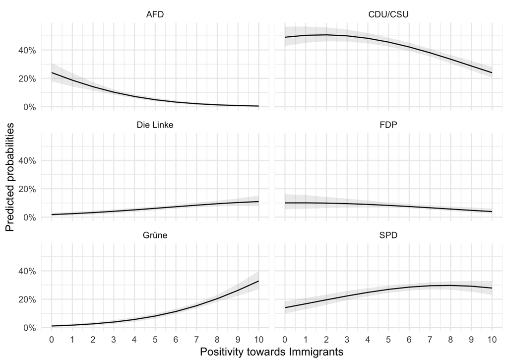

```r
library(ggplot2)
ggplot(data = pred1$plotdata, aes(
  x = imueclt,
  y = mean,
  ymin = lower,
  ymax = upper
)) +
  geom_ribbon(alpha = 0.1) + # Confidence intervals
  geom_line() + # Mean
  facet_wrap(. ~ vote_de, ncol = 2) +
  scale_y_continuous(labels = scales::percent_format(accuracy = 1)) + # % labels
  scale_x_continuous(breaks = c(0:10)) +
  theme_minimal() +
  labs(y = "Predicted probabilities",
       x = "Positivity towards Immigrants") # Always label your axes ;)
```

And here the code which puts all the predicted probabilities in one plot:

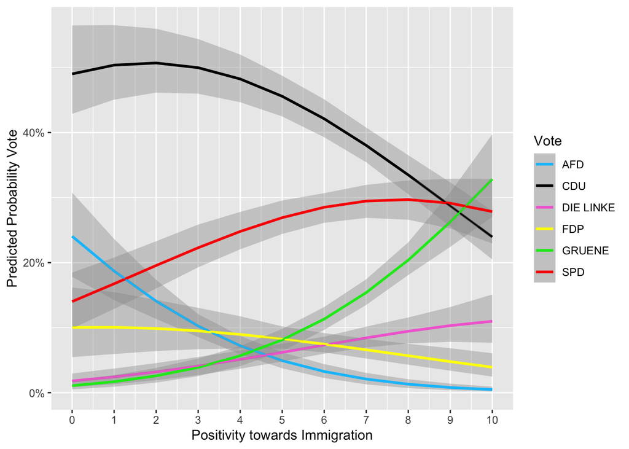

```r
ggplot(data = pred1$plotdata, aes(
  x = imueclt,
  y = mean,
  color = as.factor(vote_de)
)) +
  geom_smooth(aes(ymin = lower,
                  ymax = upper),
              stat = "identity") +
  geom_line() +
  scale_y_continuous(labels = scales::percent_format(accuracy = 1)) +
  scale_x_continuous(breaks = c(0:10)) +
  scale_color_manual(
    values = c(
      "#03c2fc",
      "#000000",
      "#f26dd5",
      "#FFFF00",
      "#00e81b",
      "#fa0000"
    ),
    name = "Vote",
    labels = c("AFD", "CDU", "DIE LINKE", "FDP",
               "GRUENE", "SPD")
  ) +
  ylab("Predicted Probability Vote") +
  xlab("Positivity towards Immigration")
```

## 3.8 `marginaleffects`

```r
library(marginaleffects)

multinom_pred_de <- plot_predictions(
  model_de,
  type = "probs",
  condition = "trstplt",
  draw = FALSE) |>
  as_tibble()

multinom_pred_de
```

```
# A tibble: 300 × 19
   rowid group estimate std.error statistic   p.value s.value conf.low conf.high
   <dbl> <fct>    <dbl>     <dbl>     <dbl>     <dbl>   <dbl>    <dbl>     <dbl>
 1     1 AFD     0.142     0.0349      4.06   4.93e-5    14.3   0.0732    0.210
 2     2 AFD     0.132     0.0316      4.17   3.04e-5    15.0   0.0698    0.194
 3     3 AFD     0.122     0.0285      4.29   1.81e-5    15.8   0.0664    0.178
 4     4 AFD     0.114     0.0258      4.41   1.05e-5    16.5   0.0631    0.164
 5     5 AFD     0.105     0.0233      4.53   5.87e-6    17.4   0.0598    0.151
 6     6 AFD     0.0977    0.0210      4.66   3.24e-6    18.2   0.0566    0.139
 7     7 AFD     0.0904    0.0189      4.78   1.78e-6    19.1   0.0533    0.128
 8     8 AFD     0.0837    0.0171      4.89   9.89e-7    19.9   0.0502    0.117
 9     9 AFD     0.0774    0.0155      5.00   5.70e-7    20.7   0.0470    0.108
10    10 AFD     0.0715    0.0140      5.10   3.48e-7    21.5   0.0440    0.0990
# ℹ 290 more rows
# ℹ 10 more variables: blgetmg <dbl>, eduyrs <int>, gndr <dbl>, hinctnta <int>,
#   imueclt <int>, stflife <int>, vote_de <fct>, yrbrn <int>, trstplt <dbl>,
#   df <dbl>
```

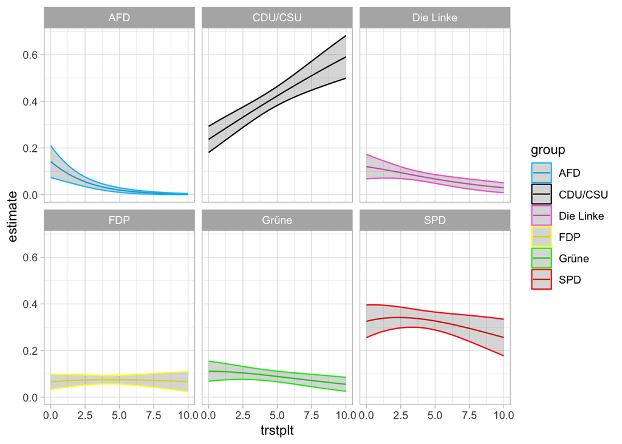

```r
multinom_pred_de |>
  ggplot(aes(trstplt, estimate, group = group, color = group)) +
  geom_line() +
  geom_ribbon(aes(ymin = conf.low, ymax = conf.high), alpha = 0.2) +
  facet_wrap(~group) +
  scale_color_manual(
    values = c(
      "#03c2fc",  # AFD
      "#000000",  # CDU
      "#f26dd5",  # DIE LINKE
      "#FFFF00",  # FDP
      "#00e81b",  # GRUENE
      "#fa0000"   # SPD
    )
  ) +
  theme_light()
```

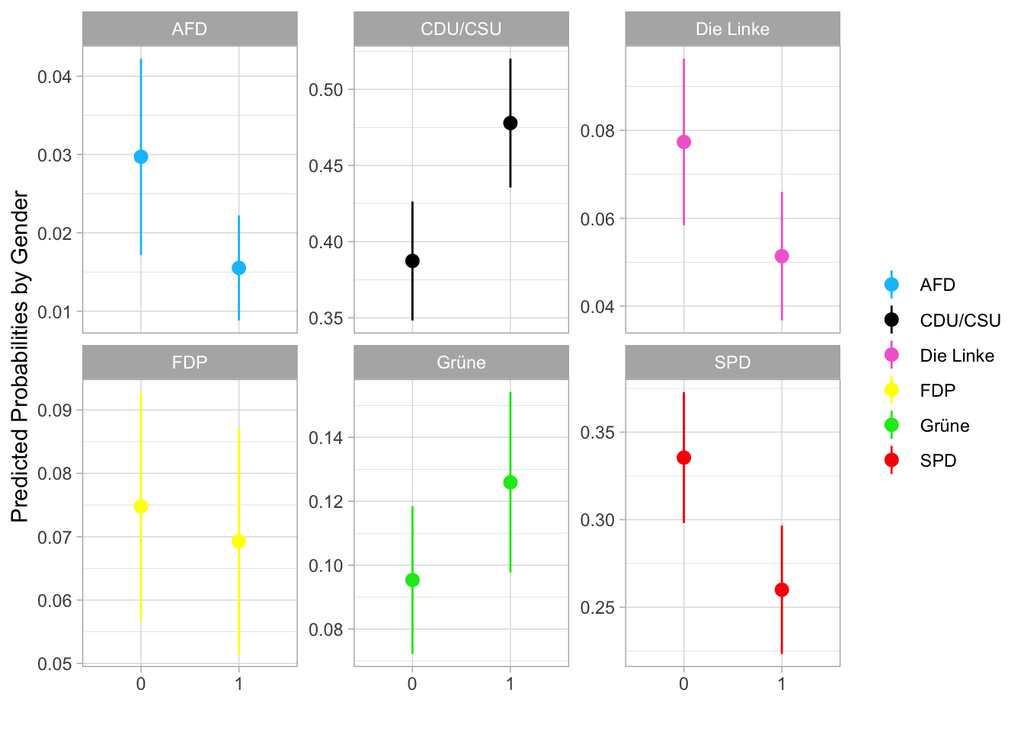

```r
multinom_pred_de_gender <- plot_predictions(
  model_de,
  type = "probs",
  condition = "gndr",
  draw = FALSE) |>
  as_tibble()

multinom_pred_de_gender |>
  ggplot(aes(gndr, estimate, group = group, color = group)) +
  geom_pointrange(aes(ymin = conf.low, ymax = conf.high)) +
  facet_wrap(~group, scales = "free_y") +
  scale_color_manual(
    values = c(
      "#03c2fc",  # AFD
      "#000000",  # CDU
      "#f26dd5",  # DIE LINKE
      "#FFFF00",  # FDP
      "#00e81b",  # GRUENE
      "#fa0000"   # SPD
    )
  ) +
  labs(
    x = "",
    y = "Predicted Probabilities by Gender",
    color = ""
  ) +
  theme(
    legend.position = "none"
  ) +
  theme_light()
```

## 3.9 Diagnostics of Multinomial Models

I have talked about diagnostics of models before. This will be the first time that we really touch upon that in models that are not linear like OLS. Usually this is a step which you should take between the building and the final interpretation of your model.

The estimates of your model change depending on several influences. The number of predictors, the scaling of your predictors, the scaling of your dependent variable or the coding of your dependent variable. All these kind of things (and many more) will have an effect on your model’s results. We need to be sure that we have a good amount of variables to account for enough variance. But we also need to make sure that we do not overfit our model, meaning that we put in too many predictors for example. We also need to make sure that our model is not biased by the scaling of our variables. This is why we need to check for multicollinearity, heteroskedasticity and other things.

We are firstly concerned with the goodness of fit of our model. In a linear model using the OLS method, we have looked at the $R^2$ and adjusted $R^2$ of the models. This tells us something about how much variance of the DV is explained by our IVs. Unfortunately, this measure does not exist for logistic or multinomial models. But the good news is that we can calculate something that is called McFadden’s Pseudo $R^2$. It is interpreted in a similar way as you would do it with a normal $R^2$ meaning that anything ranging between 0.2 and 0.4 is a result that should make us happy.

This is how you do this in R:

```r
# you obviously need to install the package first
library(pscl)
pR2(model_de)
```

```
fitting null model for pseudo-r2
```

```
          llh       llhNull            G2      McFadden          r2ML
-1925.8149013 -2158.2409526   464.8521025     0.1076924     0.2821995
         r2CU
    0.2958110
```

### 3.9.1 Hetereoskedasticity and Multicollinearity

Then there are issues of scary words like *multicollinearity* or *heteroskedasticity* (oftentimes also refered to as “heteroske-something”). These two things describe two phenomena that can skew our estimations and, in the worst case scenario, will lead to wrong inferences. Therefore, we must check for them in all different kinds of models, be it a simple model using the OLS method, or a logistic regression or a multinomial regression. There are ways to test for potential problems that might arise and also ways to work our way around them if ever we encounter them.

### 3.9.2 Multicollinearity and how to eliminate it

For now, we will only look at the potential issue of multicollinearity. It occurs when your independent variables are correlated among each other. This means that they vary very similarly in their values and measure either similar things or measure things the same way. The higher the multicollinearity within your model, the less reliable are your statistical inferences.

We can detect the amount and measure of (multi)collinearity by calculating the *Variance Inflation Factor* (VIF). It measures how much the variance of a coefficient is inflated by the correlation between our predictors. The smallest possible value is 1, which means no collinearity at all. As a common rule of thumb, VIF values above 5 deserve a closer look and values above 10 indicate a serious multicollinearity problem. (You will sometimes see thresholds of 0.2 or 0.1 mentioned in this context – those refer to the *tolerance*, which is simply 1/VIF, so low tolerance corresponds to high VIF.)

To do this in R, we use the `vif()` function of the `car` package. However, it does not work on the object of a multinomial model. Thus, we cheat our way around it and fit an auxiliary `glm()` in which our vote variable is entered as a factor with a binomial family. Be aware of what this auxiliary model actually is: with a multi-category factor as the outcome, `glm()` fits a *single* binary logistic regression of the first factor level (the AFD) against all other parties combined – it is **not** our multinomial model. That is fine for our purpose here, because the VIF is a property of the *predictors* (it is computed from the correlations among the IVs), not of the outcome. But you should not interpret this auxiliary model’s coefficients.

```r
model_vif <-
  glm(
    as.factor(vote_de) ~ imueclt  + stflife + trstplt + blgetmg +
      gndr + yrbrn + eduyrs + hinctnta,
    data = ess_clean,
    family = binomial()
  )

car::vif(model_vif)
```

```
 imueclt  stflife  trstplt  blgetmg     gndr    yrbrn   eduyrs hinctnta
1.168846 1.253236 1.142468 1.041481 1.038761 1.108050 1.245434 1.311167
```

Based on the results, we can see that multicollinearity is no concern in our model: all VIF values are between 1.0 and 1.4, i.e. very close to the minimum of 1. As a reading aid: a VIF of 1 means that a predictor is not correlated with the other predictors at all, values between 1 and 5 indicate modest correlation (which is quite normal), values between 5 and 10 indicate strong correlation, and values above 10 signal a serious problem.

If, however, you should encounter issues of multicollinearity, you should test the VIFs for different versions of your model by starting to drop the IV with the highest VIF and see how that affects your VIFs overall. Or you check the variables which have high values, see if theoretically speaking they measure similar things, and combine them into a single measure.

It is important to do this step in order to test the validity and reliability of our models!

## 3.10 Goodness of Fits and its other measures

You have seen me use the term goodness of fit before and that this becomes very important in quantitative research when you try to model statistical relationships. Until now, we have always only modeled one model and then interpreted its coefficients and model values. We have seen the $R^2$ and adjusted $R^2$ and we have mostly seen bad OLS models which showed very low values in both these measures. However, this measure does not always exist for generalized linear models. Thus, statisticians have come up with other ways to compare models and their *goodness of fit*. As a rule of thumb, we should always favor models which explain as much as possible by not making too many (strong) assumptions and overfitting our predictors, e.g. adding too many in one regression etc. In one of your introduction to (political) science classes, you might have heard of Ockham’s razor; this is the same idea but for statistical models.

Goodness of fit in our case refers to how well the model which we have constructed, fits the set of our made observations. Thus, goodness of fit somewhat measures the discrepancy between our observed and expected values given our model. If we do not have an adjusted $R^2$, we need to use other information criteria to determine which model fits best our data. There is quite an abundance of criteria which come to mind. Some of them are related to specific kinds of statistical models, whereas some are more general. The two which I would like to mention here are the **AIC** and the **BIC**.

### 3.10.1 AIC (Akaike Information Criterion)

What would a similar model look like? Well, if we dropped one of our IVs for example, we would alter the model a bit but keep its global structure. In that case, we would generate a second but different AIC. Comparing the AIC then tells us something about which model (meaning which composition of model) indicates a better fit.

What is a better AIC? The **lower** AIC indicates that the model fits our data better than the model with the higher AIC. This is simply a mathematical measure. Stand-alone values of the AIC do not tell us much. They need to be considered in comparison to other values.

### 3.10.2 BIC (Bayesian Information Criterion)

Bayesian Statistics [^1] are super fascinating and I will include them wherever I can. Luckily, the BIC is very common and is to the AIC what the adjusted $R^2$ is to the $R^2$. This means that it is a “stricter” measure of goodness of fit than the AIC. It is quite similar to the AIC but differs in that it penalizes you for adding “less useful” variables to your model (potentially *overfitting* or overcomplexifing your model). Thus, similarly to the AIC, we should also favor the **lower** BIC!

King, Gary, Michael Tomz, and Jason Wittenberg. 2000. “Making the Most of Statistical Analyses: Improving Interpretation and Presentation.” *American Journal of Political Science* 44 (2): 347–61. https://doi.org/10.2307/2669316.

[^1]: The second school of doing statistics. What we are doing is called *frequentist* statistics. Bayesian statistics are a bit more complicated and require a different way of thinking about statistics but they are the more intuitive way of conducting statistics (without p-values but with something you could call *certainty*). They are also more computationally expensive and thus, have only gained traction over the recent decades. They are gaining more and more popularity. If you are interested in learning more about them, I recommend the book by Richard McElreath (2016) [*Statistical Rethinking: A Bayesian Course with Examples in R and Stan*](https://github.com/rmcelreath/stat_rethinking_2024). He also has lectures on YouTube that follow the book. Definitely worth a try!